# Midterm Decision

6/4/2020

```r
library(mosaic)
library(car)
library(tidyverse)
library(readr)
library(pander)
```

## Decision

**I have decided to keep my score on the MATH 425 Midterm.**

## Reasoning and Analysis

After examinging the data provided on past MATH 425 students and different metrics about them, I have reached a prediction of 85.40%. Given that no partial credit is awarded on this exam and that it consists of 25 multiple choice answers, my official prediction will be 84%. My method of model selection is as follows:

A pairs plot was constructed with the original data, which was examined, and consequently decided that the first explanatory variable used would be the midterm score. The regression model was constructed, summarized, and then it became the new source for the pairs plot. This process was completed 9 times, resulting in a model that estimated 9 parameters. Variables that then became insignificant were removed from the regression, resulting in a final regression model estimating only 3 parameters, all of which are significant. The diagnostic plots were then created and evaluated.

The variables that were used are the Midterm variable, as well as the Magic Two Groups variable. Due to insignificance, the interaction of these variables was removed, which creates a two-lines regression model only allowing for the intercepts to change.

### Model

#### Pairs Plots

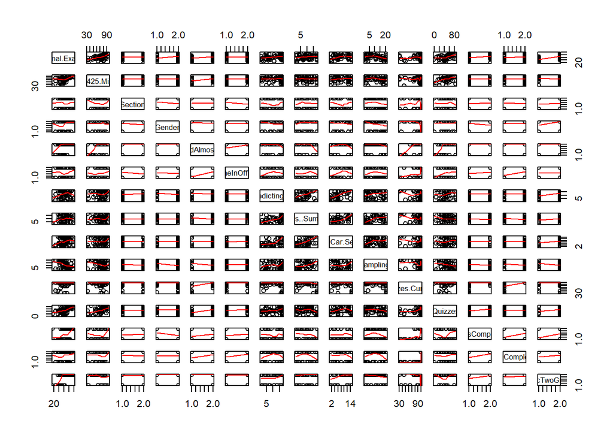

```r
pairs(pastgrades, panel=panel.smooth)
```

A completely detailed process of model selection is not included in this document, though it can be provided if desired. The original pairs plot is used, which was initially used to see the correlation between the “Math.425.Midterm” variable. The final pairs plot, which uses the residuals and fitted values from the regression model, is also included:

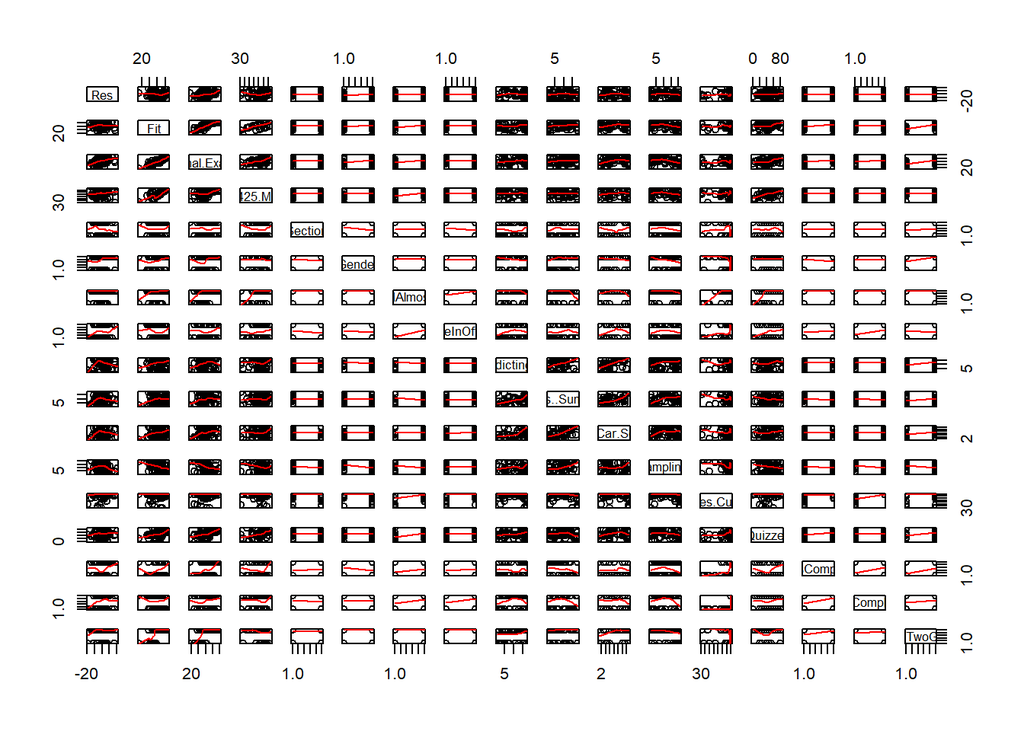

```r
lm.9 <- lm(Final.Exam ~ Math.425.Midterm + MagicTwoGroups, data = pastgrades)
pairs( cbind(Res = lm.9$res, Fit = lm.9$fit, pastgrades), panel=panel.smooth)
```

Though a few variables do look a bit suspicious, through exploration they were deemed as insignificant.

#### True Model

$$\underbrace{Y_i}_\text{Final Exam Score}=\beta_0+\beta_1\underbrace{X_{1i}}_\text{Midterm Score}+\beta_2\underbrace{X_{2i}}_\text{Magic Two Groups}+\epsilon_i$$

```r
lm.9 <- lm(Final.Exam ~ Math.425.Midterm + as.factor(MagicTwoGroups), data = pastgrades)
```

#### Regression Model

A plot of the fitted regression model is provided. The green line represents what the fitted regression model would be if the “dummy variable” of Magic Group Two had not been used. This was included to demonstrate how much of a difference adding the factor of the MagicGroupTwo variable makes. The blue lines are the prediction interval for my predicted final exam score, and the blue asterisk is the actual value of my prediction.

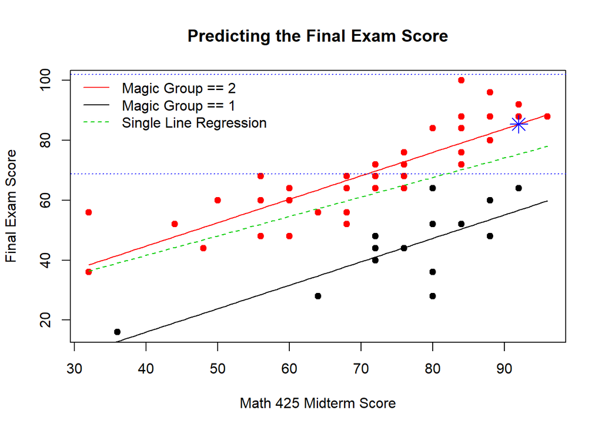

```r
plot(Final.Exam ~ Math.425.Midterm, data = pastgrades, pch = 19, col = as.factor(MagicTwoGroups), xlab = "Math 425 Midterm Score", ylab = "Final Exam Score", main = "Predicting the Final Exam Score")
b <- coef(lm.9)
curve(b[1] + b[2]*x, col = "black", add = TRUE)
curve(b[1] + b[2]*x + b[3], add = TRUE, col = "red")
legend("topleft", legend = c("Magic Group == 2", "Magic Group == 1", "Single Line Regression"), col = c("red","black","green3"), bty = "n", lty = c(1,1,2))
points(x = 92, y = 85.40324, col = "blue", pch = 8, cex = 2)
abline(h=68.80353, col = "blue", lty = 3)
abline(h=102.003, col = "blue", lty = 3)

fake.lm <- lm(Final.Exam ~ Math.425.Midterm, data = pastgrades)
c <- coef(fake.lm)
curve(c[1] + c[2]*x, lty = 2, add = TRUE, col = "green3")
```

```r
summary(lm.9) %>% pander()
```

|  | Estimate | Std. Error | t value | Pr(>\|t\|) |
| --- | --- | --- | --- | --- |
| **(Intercept)** | -15.29 | 5.83 | -2.623 | 0.01127 |
| **Math.425.Midterm** | 0.7824 | 0.07091 | 11.03 | 1.461e-15 |
| **as.factor(MagicTwoGroups)2** | 28.71 | 2.448 | 11.73 | 1.361e-16 |

Fitting linear model: Final.Exam ~ Math.425.Midterm + as.factor(MagicTwoGroups)

| Observations | Residual Std. Error | $R^2$ | Adjusted $R^2$ |
| --- | --- | --- | --- |
| 58 | 8.059 | 0.8027 | 0.7955 |

```r
predict(lm.9, data.frame(Math.425.Midterm = 92, MagicTwoGroups = 2), interval = "prediction")
```

```
##        fit      lwr     upr
## 1 85.40324 68.80353 102.003
```

As is shown, each of the 3 estimates obtained for the parameters are significant. This is also where I made my prediction, using my midterm score of a 92%, and assuming that for me, MagicGroupTwo == 2.

A prediction interval was also constructed, which gives a lower bound of 68.80% and an upper bound of 102.00%. This is of course not possible, but was nevertheless added to the plot.

#### Diagnostic plots

```r
par(mfrow=c(1,3))
plot(lm.9,which=1)
qqPlot(lm.9$residuals)
```

```
## [1] 54 47
```

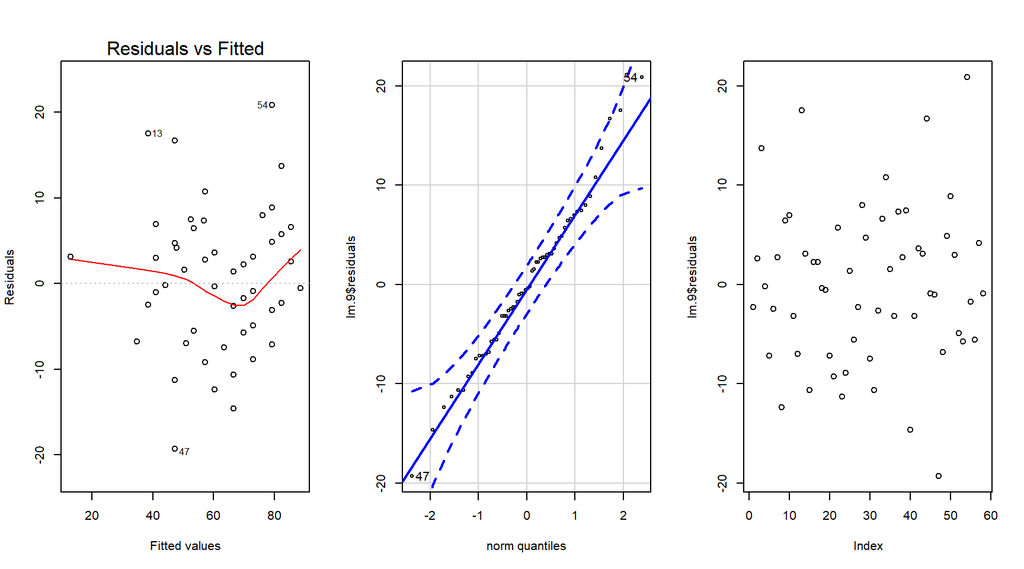

```r
plot(lm.9$residuals)
```

Based on these diagnostic plots, it looks like we are able to trust the results of our regression. Constant variance is not an issue, however linearity does rais some concerns considering the parabolic shape of the residuals. This was, however, not deemed as significant enough to disregard the results of our analysis, and as previously discussed, the other variables which were initially used and may be the source of this patterns were found to be insignificant. The residuals are definiely normally distributed, and there is no apparent pattern in the residuals vs order plot.

## Conclusion

The summary of our regression model shows us that we have an adjusted $R^2$ value of 0.7955, which can be interpreted to mean that 79.55% of the variation in the data is explained by the regression line. The decision to keep my score was decided based on the fact that 92% is higher than 84% (my predicted Final Exam score), which would have a greater positive effect on the final score in the class.

I am able to make this conclusion due to each of the coefficients in the model being significant, and because our diagnostic plots all more or less checked out.